# Untitled

# WEEK 5: Dimensionality reduction techniques:

## Presenting human data

The human data analyzed here is from 155 all around the world. The variables in the dataset are

Edu2.FM = Proportion of females with at least secondary education divided by proportion of males with at least secondary education  
Labo.FM = Proportion of females in the labour force divided by proportion of males in the labour force  
Edu.Exp = Expected years of schooling  
Life.Exp = Life expectancy at birth  
GNI = Gross National Income per capita  
Mat.Mor = Maternal mortality ratio  
Ado.Birth = Adolescent birth rate  
Parli.F = Percetange of female representatives in parliament

and they are summarised below. For example, life expectancy ranges from 49 year to 83.5 years (median 74 years). Huge range can be seen also for example for Gross National income (GNI) which ranges from 581 to 123,124 per capita. Huge range can be seen for education years also (5.4-20.2 years). Not many variables are normally scaled, but they are right or left-tailed. A strong positive correlation can bee seen between GNI and life expectancy (r=0.627)

```
##     Edu2.FM          Labo.FM          Edu.Exp         Life.Exp
##  Min.   :0.1717   Min.   :0.1857   Min.   : 5.40   Min.   :49.00
##  1st Qu.:0.7264   1st Qu.:0.5984   1st Qu.:11.25   1st Qu.:66.30
##  Median :0.9375   Median :0.7535   Median :13.50   Median :74.20
##  Mean   :0.8529   Mean   :0.7074   Mean   :13.18   Mean   :71.65
##  3rd Qu.:0.9968   3rd Qu.:0.8535   3rd Qu.:15.20   3rd Qu.:77.25
##  Max.   :1.4967   Max.   :1.0380   Max.   :20.20   Max.   :83.50
##       GNI            Mat.Mor         Ado.Birth         Parli.F
##  Min.   :   581   Min.   :   1.0   Min.   :  0.60   Min.   : 0.00
##  1st Qu.:  4198   1st Qu.:  11.5   1st Qu.: 12.65   1st Qu.:12.40
##  Median : 12040   Median :  49.0   Median : 33.60   Median :19.30
##  Mean   : 17628   Mean   : 149.1   Mean   : 47.16   Mean   :20.91
##  3rd Qu.: 24512   3rd Qu.: 190.0   3rd Qu.: 71.95   3rd Qu.:27.95
##  Max.   :123124   Max.   :1100.0   Max.   :204.80   Max.   :57.50
```

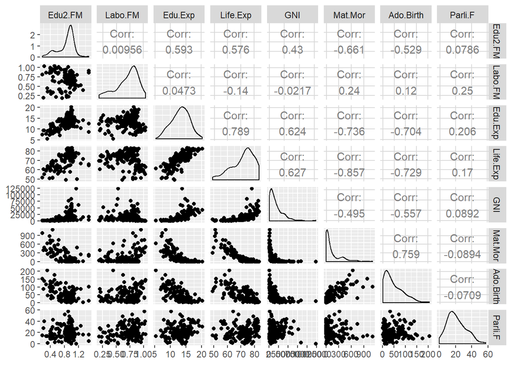

## Pricipal component analysis

First, a pricipal component analysis was performed with unstandardized human data. There PC1 expalined 99.99% of the variation of the data and only 0.01% remained for the PC2. As shown from the biblot, GNI was the variable mainly determining the PC1. And without standardization all the effects from the other variables can not be interpreted.

Standardize the variables in the human data and repeat the above analysis. Interpret the results of both analysis (with and without standardizing). Are the results different? Why or why not? Include captions (brief descriptions) in your plots where you describe the results by using not just your variable names, but the actual phenomenons they relate to. (0-4 points)

```
##   PC1   PC2   PC3   PC4   PC5   PC6   PC7   PC8
## 99.99  0.01  0.00  0.00  0.00  0.00  0.00  0.00
```

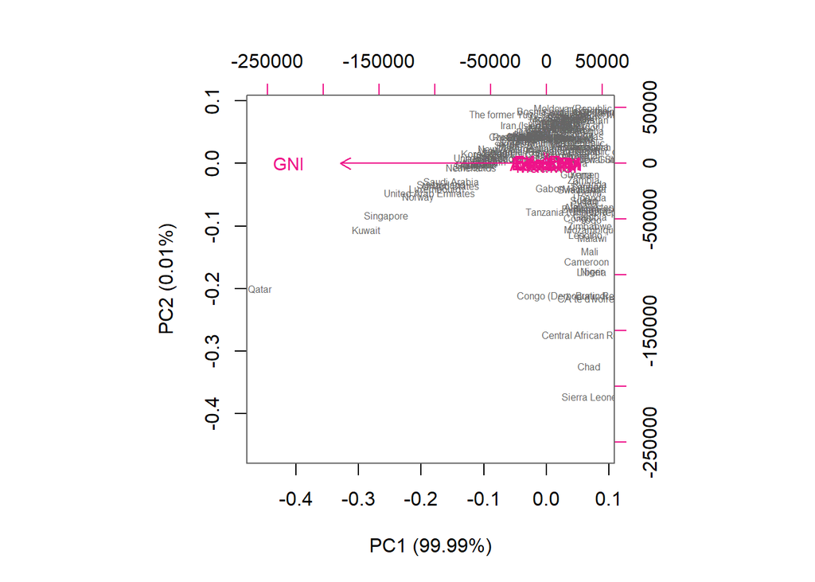

With standardized human data, the pricipal component analysis gives a more informative results not fully dominated by GNI. Now, PC1 explaines 53.6% of the variability, PC1 16.2% and the rest remains for the other PCs. Now we can see, that gross national income per capita (GNI), education years (Edu.exp) and life expentacy (Life.exp) are all very closely correlated.

```
## Importance of components:
##                           PC1    PC2     PC3     PC4     PC5     PC6
## Standard deviation     2.0708 1.1397 0.87505 0.77886 0.66196 0.53631
## Proportion of Variance 0.5361 0.1624 0.09571 0.07583 0.05477 0.03595
## Cumulative Proportion  0.5361 0.6984 0.79413 0.86996 0.92473 0.96069
##                            PC7     PC8
## Standard deviation     0.45900 0.32224
## Proportion of Variance 0.02634 0.01298
## Cumulative Proportion  0.98702 1.00000
```

```
##  PC1  PC2  PC3  PC4  PC5  PC6  PC7  PC8
## 53.6 16.2  9.6  7.6  5.5  3.6  2.6  1.3
```

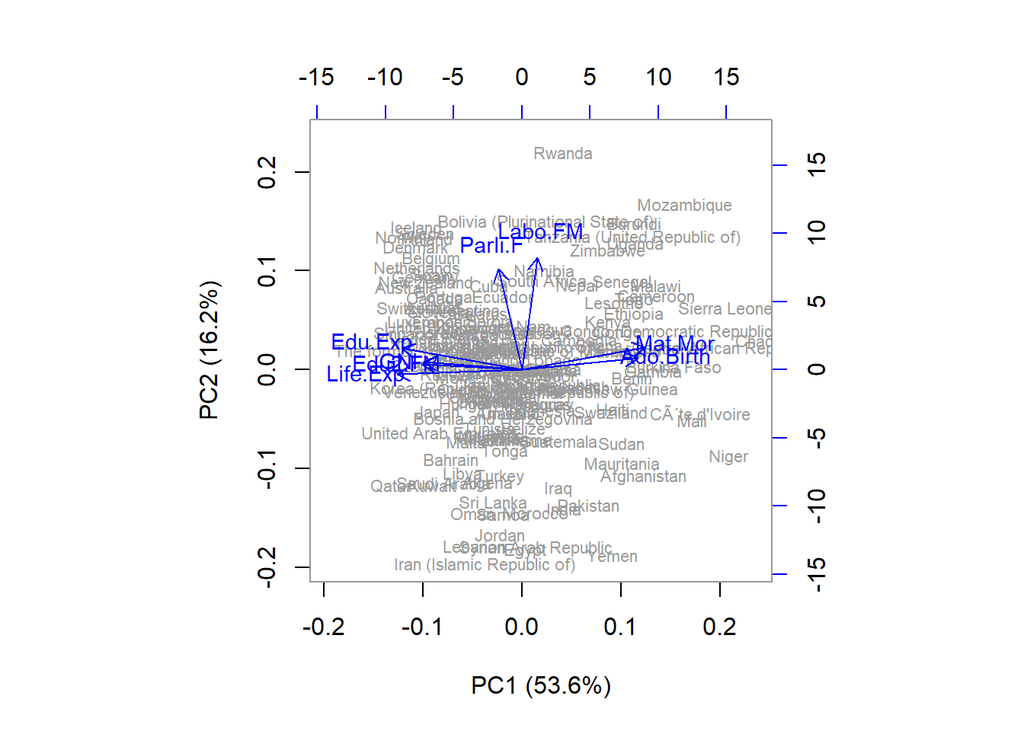